# P2 Segunda entrega

2022-06-24

# *INTRODUCCIÓN*

- **Relevancia:**El proyecto de investigación presenta como los hábitos alimenticios pueden influir en el rendimiento académico de cada alumno, esto reflejado en su promedio ponderado. Esta investigación nos ayudará a concientizar a la población utecsina sobre la importancia de una alimentación saludable, promover buenos hábitos alimenticios para aportar al desarrollo integral de los alumnos. Los resultados obtenidos serán un aporte para la universidad, contribuirá en el desarrollo académico de cada alumno y servirá de referencia para estudios futuros.

# *Objetivos*

- **Objetivo General:**Determinar la relación entre los malos hábitos alimenticios y el rendimiento académico en los estudiantes de la Universidad de Ingeniería y Tecnología.
- **Objetivo Específico:**Identificar los hábitos alimenticios de los estudiantes de la Universidad de Ingeniería y Tecnología, así como también Establecer la relación entre los hábitos alimenticios saludables y no saludables con el rendimiento académico en base a el promedio de cada alumno.

# *DATOS*

- **Recolección de dato:**En primer lugar, para recolectar información se realizó una encuesta virtual a todos los estudiantes posibles de la Universidad de Ingeniería y Tecnología (sin distinción de ciclo, carrera, sexo, etc.) utilizando la plataforma de google forms. Las estrategias que utilizamos para tener un mayor alcance de alumnos y optimizar el tiempo fue un sorteo de 3 almuerzos y 30 soles. En segundo lugar, se realizó los sorteos una vez obtenida nuestra muestra objetiva y se hizo llegar los premios establecidos. Finalmente se analizó e interpretó los datos obtenidos para dar respuesta a nuestro problema de investigación.
- **Población:**La población con la que se realizó la investigación fueron los estudiantes de la Universidad de Ingeniería y Tecnología (UTEC), nuestra población posee el perfil común de jóvenes en relación a su alimentación diaria. Además, se tomó en cuenta como criterio la accesibilidad y que cumplieran con los criterios para la inclusión en la investigación, las cuales son: estudiantes de la universidad de primer a décimo ciclo, ambos sexos y de todas las carreras.
- **Muestra:**La muestra de este estudio se compone de 205 estudiantes, 53.2% son varones, 45.5% son mujeres y el 1.3% prefiere no decirlo. El rango de edad de esta muestra oscila entre los 15 y 22 años de edad. Los estudiantes de esta investigación cursan desde el primer al décimo ciclo de educación superior en las 12 carreras de la Universidad de Ingeniería y Tecnología.
- **Muestreo:**El muestreo utilizado para la presente investigación es aleatorio simple. Debido a que a cada alumno se le asigna un número correlativo y a través del método al azar se va seleccionando hasta completar la muestra requerida.
- **Variables:**
  - **Edad**, pertenece al tipo de variable numérica discreta y su restricción es que sea un entero no negativo.
  - **Cachimbo**, pertenece al tipo de variable categórica nominal y su restricción sería que este sea binomial.
  - **Ciclo**, pertenece al tipo de variable categórica ordinal y su restricción es que tome valores enteros mayores 0 y menores que 10.
  - **Promedio ponderado (ciclo anterior)**, pertenece al tipo de variable numérica continua y su restricción es que no tome valores negativos y que sean mayores que 0 y menores que 20.
  - **Consideración de promedio (ciclo actual)**, pertenece al tipo de variable tipo numérica continua y su restricción es que no tome valores negativos y que sean mayores que 0 y menores 20.
  - **Sexo**, pertenece al tipo de variable categórica nominal y su restricción es que no sea numérica.
  - **Carrera**, pertenece al tipo de variable categórica nominal y su restricción es que solo sean carreras de la universidad.
  - **Estatura**, pertenece al tipo de variable numérica continua y su restricción es que tome valores enteros no negativos.
  - **Peso**, pertenece al tipo de variable numérica continua y su restricción es que tome valores enteros no negativos.
  - **Consumo diario de agua en litros**, pertenece al tipo de variable numérica continua y su restricción es que tome valores enteros no negativos.
  - **Número de frutas consumidas diariamente**, pertenece al tipo de variable numérica discreta y su restricción es que tome valores de mayores que 0 y menores que 5
  - **Estilo de vida alimenticio**, pertenece al tipo de variable categórica nominal y su restricción es que no presente orden y que no sea numérica.
  - **Alimentos más consumidos diariamente**, pertenece al tipo de variable categórica nominal y su restricción es que no sea numérica.
  - **Alimentos secundarios que más consume diariamente**, pertenece al tipo de variable categórica nominal y su restricción es que no sea numérica
  - **Cumplimiento de las 3 comidas diarias recomendadas**, pertenece al tipo de variable categórica nominal y su restricción es que este sea binomial.
  - **Síntomas percibidos por falta de alimentación**, pertenece al tipo de variable categórica nominal y su restricción es que no presente orden y no numérica
  - **Turno de mayor cantidad de consumo de alimentos**, pertenece al tipo de variable categórica ordinal y su restricción es sea no numérica.
  - **Frecuencia semanal de consumo de comida chatarra**, pertenece al tipo de variable numérica discreta y su restricción es que no tome valores decimales y negativos.
  - **Padeces o has padecido gastritis**, pertenece al tipo de variable categórica nominal y su restricción sería que este sea binomial(sacar el 80%)
  - **Consideración porcentual de sus hábitos alimenticios**, pertenece al tipo de variable numérica continua y su restricción es que no tome valores enteros negativos.
  - **Tienes conocimiento de cuantas calorías consumes diariamente**, pertenece al tipo de variable categórica nominal y su restricción es que sea binomial.

# Limpieza de datos

### Llamamos a la librería readr

```r
library(readr)
```

### Denominamos como BDD a nuestra base de datos y asignamos el tipo de variable para cada columna

```r
BDD <- read_csv("Base de datos4.csv",col_types="ccnccnnccnnnnccccccncnc")
```

```r
dim(BDD)
```

```
## [1] 205  23
```

### Eliminamos las columnas que no necesitamos

```r
BDD[, -1 ]->BDD1
BDD1[, -1 ]->BDD2
```

### Asignamos el nombre que deseamos para cada tipo variable

```r
names(BDD2) <- c("Edad","Cachimbo","Ciclo","Promedio","PromedioC","Sexo","Carrera","Estatura","Peso","Consumo en litros de agua por dia","Consumo de frutas por dia","Tipo de dieta","Principal alimento diario","Segundo alimento mas consumido","Cumple las 3 comidas diarias","Sintomas por falta de alimentacion","Turno de mayor alimentacion", "Frecuencia de comida chatarra por semana","Gastritis","Porcentaje saludable del habito alimenticio","Conocimiento de calorias diarias")
```

### Llamamos a la librería dplyr

```r
library(dplyr)
```

### Cambiamos los datos de variable consumo de litros de agua por día

```r
BDD2 %>% mutate(`Consumo en litros de agua por dia` =
        ifelse(`Consumo en litros de agua por dia` == "1/2lt", 0.50,
        ifelse(`Consumo en litros de agua por dia` =="1lt", 1,
        ifelse(`Consumo en litros de agua por dia` =="2lt", 2,
        ifelse(`Consumo en litros de agua por dia` =="3lt", 3,
        ifelse(`Consumo en litros de agua por dia` =="4lt", 4,
        ifelse(`Consumo en litros de agua por dia` =="5lt", 5, `Consumo en litros de agua por dia`
        ))))))) -> BDD2
```

### Cambiamos los datos de la variable Principal alimento diario

```r
BDD2 %>% mutate(`Principal alimento diario` =
        ifelse(`Principal alimento diario` == "Carnes( pollo, pescado, res, etc )", "Carnes",`Principal alimento diario`))-> BDD2
```

### Cambiamos los datos de la variable Segundo alimento más consumido

```r
BDD2 %>% mutate(`Segundo alimento mas consumido` =
        ifelse(`Segundo alimento mas consumido` == "Carnes(pollo, res, pescado, etc)", "Carnes",`Segundo alimento mas consumido`))-> BDD2
```

### Cambiamos los datos de la variable Porcentaje saludable del hábito alimenticio

```r
BDD2 %>% mutate(`Porcentaje saludable del habito alimenticio` =
          ifelse(`Porcentaje saludable del habito alimenticio` == 7.00, NA ,`Porcentaje saludable del habito alimenticio`))-> BDD2
```

```r
library(ggplot2)
```

# Estadística Descriptiva:

## Turno de alimentos:

Comer las tres comidas básicas diarias es vital para poder ejercer nuestras actividades académicas de manera óptima, sin embargo, según la OMS la comida más importante es el desayuno, pues consumir en poca cantidad o no ingerir alimentos en este turno puede causar falta de concentración, mareos, fatiga, disminuye la capacidad de concentración y si eso persiste puede ocasionar daños neuronales. Además, afirma que el comer en exceso después del ayuno, solo por saciar el hambre puede afectar el desempeño académico progresivo.

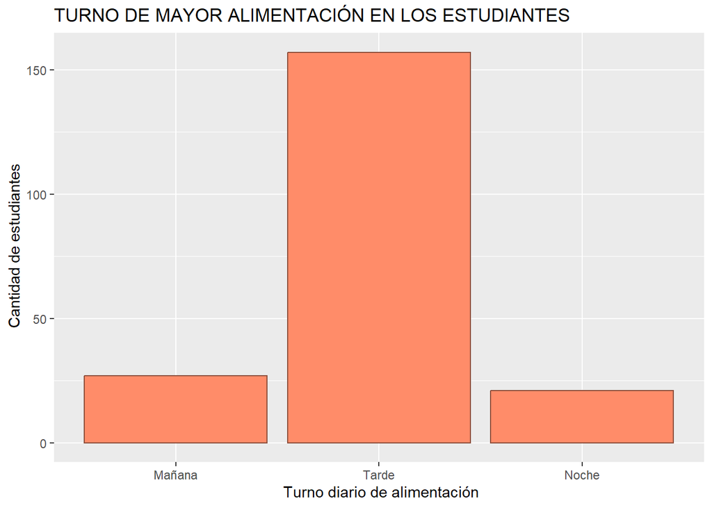

```r
BDD2$`Turno de mayor alimentacion`= factor(BDD2$`Turno de mayor alimentacion`, levels=c("Mañana", "Tarde", "Noche"))


ggplot(data=BDD2)+ geom_bar(position = "dodge",  aes(`Turno de mayor alimentacion`),fill
                       = "salmon1", colour = "salmon4")+ labs(title= "TURNO DE MAYOR ALIMENTACIÓN EN LOS ESTUDIANTES ", x =" Turno diario de alimentación", y =" Cantidad de estudiantes")
```

## Variable alimentos más consumidos diariamente:

De los 205 alumnos encuestados, 108 estudiantes consumen carnes a diario. Esta proteína se ubica en el último grupo de la pirámide alimenticia, por lo que deben ser consumidas de forma opcional, consumirla menos veces, pero de mayor calidad. Según el informe elaborado por la OMS, la ingesta diaria de carnes asocia al riesgo de padecer diversas enfermedades crónicas, cardiovasculares o cáncer. En consecuencia, más del 50% de estudiantes encuestados no llevan una dieta saludable afectando el proceso cognitivo y la capacidad de concentración, memoria o atención, además corren el riesgo de sufrir alguna enfermedad crónica en un futuro.

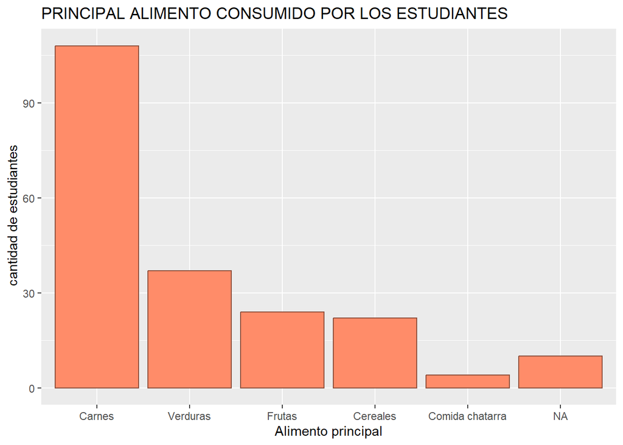

```r
BDD2$`Principal alimento diario`= factor(BDD2$`Principal alimento diario`,levels=c("Carnes", "Verduras", "Frutas", "Cereales", "Lacteos", "Comida chatarra"))

ggplot(data = BDD2) + geom_bar(position = "dodge",  aes(`Principal alimento diario`),fill
                       = "salmon1", colour = "salmon4")+ labs(title= "PRINCIPAL ALIMENTO CONSUMIDO POR LOS ESTUDIANTES", x ="Alimento principal", y =" cantidad de estudiantes")
```

## Variable consumo diario de agua en litros:

El presidente del instituto de investigación ha asegurado que una buena hidratación mejora la capacidad cognitiva y el rendimiento intelectual de los alumnos. Pues asegura que una mala hidratación provoca cansancio, dolor de cabeza, y deshidratación. Además, se recomienda consumir dos litros diarios de agua en el caso de varones y 1.5 litros en el caso de mujeres, pues un exceso de ello también causa desorientación, mareos y dolor de cabeza.

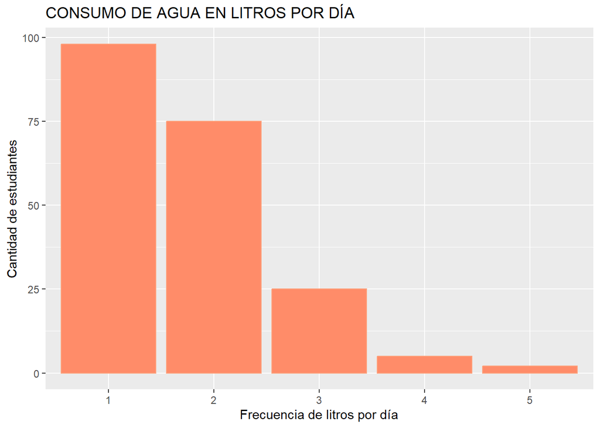

```r
ggplot(data=BDD2, aes(factor(`Consumo en litros de agua por dia`))) +
  geom_bar( col= "lightsalmon1", fill="salmon1") + labs(title = "CONSUMO DE AGUA EN LITROS POR DÍA", x ="Frecuencia de litros por día", y="Cantidad de estudiantes")
```

# Análisis de datos

Utilizamos estos descriptores numéricos debido a que mediante las conclusiones que sacaremos de cada variable podamos tener una vista general de toda nuestra base de datos, utilizaremos promedios para hallar el centro de la masa de los datos, utilizaremos la mediana para poder saber la distribución de los datos ya que la mediana parte en dos mitades los datos, utilizaremos la moda para saber qué valor se repite más en cada variable.

## Variable Promedio

### Promedio

```r
mean(BDD2$Promedio, na.rm = TRUE)
```

```
## [1] 15.06376
```

### Mediana

```r
median(BDD2$Promedio, na.rm = TRUE)
```

```
## [1] 15.3
```

### Moda

```r
library(modeest)
mfv(BDD2$Promedio, na_rm = TRUE)
```

```
## [1] 15
```

# Variable Consumo de frutas por dia

### Promedio

```r
mean(BDD2$`Consumo de frutas por dia`)
```

```
## [1] 1.95122
```

### Mediana

```r
median(BDD2$`Consumo de frutas por dia`)
```

```
## [1] 2
```

### Moda

```r
library(modeest)
```

```r
mfv(BDD2$`Consumo de frutas por dia`)
```

```
## [1] 2
```

# Variable Frecuencia de comida chatarra por semana

### Promedio

```r
mean(BDD2$`Frecuencia de comida chatarra por semana`)
```

```
## [1] 1.97561
```

### Mediana

```r
median(BDD2$`Frecuencia de comida chatarra por semana`)
```

```
## [1] 2
```

### Moda

```r
library(modeest)
```

```r
mfv(BDD2$`Frecuencia de comida chatarra por semana`)
```

```
## [1] 2
```

# Variable Porcentaje saludable del habito alimenticio

### Promedio

```r
mean(BDD2$`Porcentaje saludable del habito alimenticio` , na.rm = TRUE)
```

```
## [1] 0.6255882
```

### Mediana

```r
median(BDD2$`Porcentaje saludable del habito alimenticio` , na.rm = TRUE)
```

```
## [1] 0.65
```

### Moda

```r
library(modeest)
```

```r
mfv(BDD2$`Porcentaje saludable del habito alimenticio` , na_rm = TRUE)
```

```
## [1] 0.7
```

# *Relación entre variables:*

## *Gráfica 1*:

En esta gráfica podemos observar el promedio en el eje Y y en el eje X el porcentaje saludable del hábito alimenticio y cuando interpretamos la gráfica nos damos cuenta de que las personas con un mejor hábito alimenticio es decir que tienden a llegar a 1 que equivale tener un buen hábito alimenticio, son las que poseen un promedio de notas mayor y en cambio las que no se alejan de 1, tienden a tener un promedio bajo.

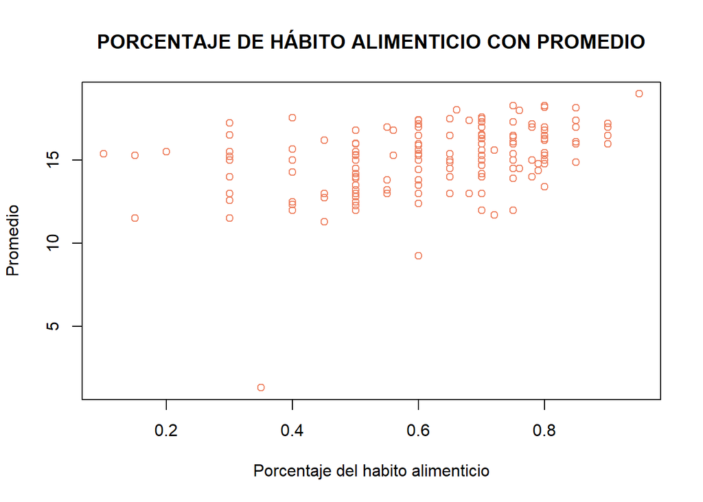

```r
plot(x = BDD2$`Porcentaje saludable del habito alimenticio`, y = BDD2$Promedio,
     xlab = "Porcentaje del habito alimenticio" , ylab = "Promedio", main="PORCENTAJE DE HÁBITO ALIMENTICIO CON PROMEDIO", col="salmon2")
```

## *Gráfica 2:*

En esta gráfica podemos observar la cantidad de estudiantes que cumplen sus 3 comidas diarias, así como también en que turno del día consumen mayores alimentos y nos damos cuenta de que la mayoría de los estudiantes que se alimentan más en las tardes son los que más cumplen al comer sus 3 comidas diarias al día.

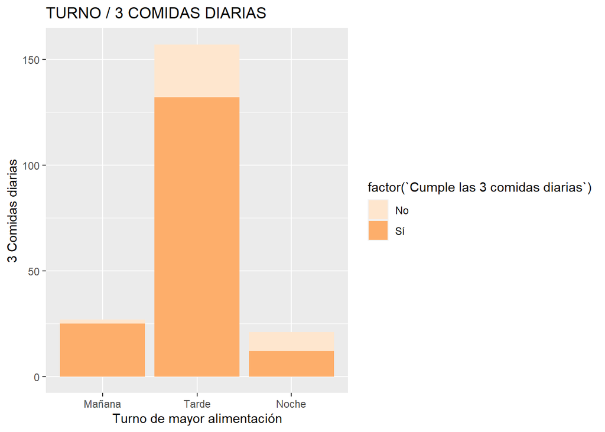

```r
ggplot(BDD2, aes(factor(`Turno de mayor alimentacion`), fill = factor(`Cumple las 3 comidas diarias`))) +
  geom_bar(position = "stack") + labs(title = "TURNO / 3 COMIDAS DIARIAS", x ="Turno de mayor alimentación", y ="3 Comidas diarias") + scale_fill_brewer(palette = "Oranges")
```

## *Gráfica 3:*

En esta gráfica podemos observar cantidad de estudiantes y la frecuencia que consumen comida chatarra por semana, nos damos cuenta de que la mayoría de los estudiantes consumen comida chatarra dos veces por semana.

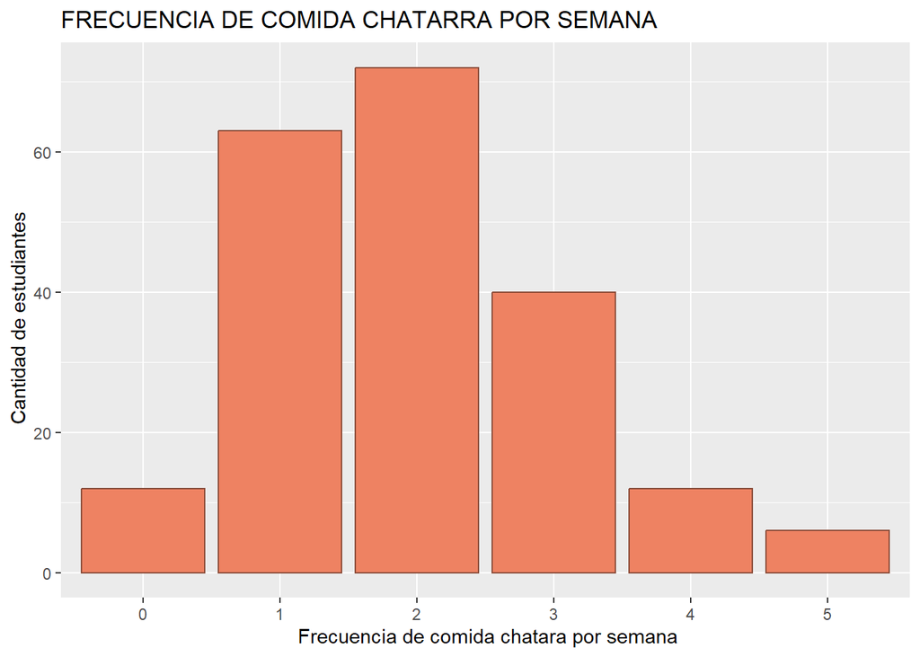

```r
BDD2$`Frecuencia de comida chatarra por semana`= factor(BDD2$`Frecuencia de comida chatarra por semana`, levels=c("0", "1", "2", "3", "4", "5"))
ggplot(data = BDD2) + geom_bar(position = "stack", aes(`Frecuencia de comida chatarra por semana`),fill = "salmon2", colour = "salmon4")+ labs(title= "FRECUENCIA DE COMIDA CHATARRA POR SEMANA ", x =" Frecuencia de comida chatara por semana", y =" Cantidad de estudiantes")
```

## *Gráfica 4:*

En esta gráfica observamos el principal alimento diario y las personas que padecen o no de gastritis, según lo observados podemos darnos cuenta de que los estudiantes que no tienen gastritis consumen más carnes, cereales, frutas, verduras .

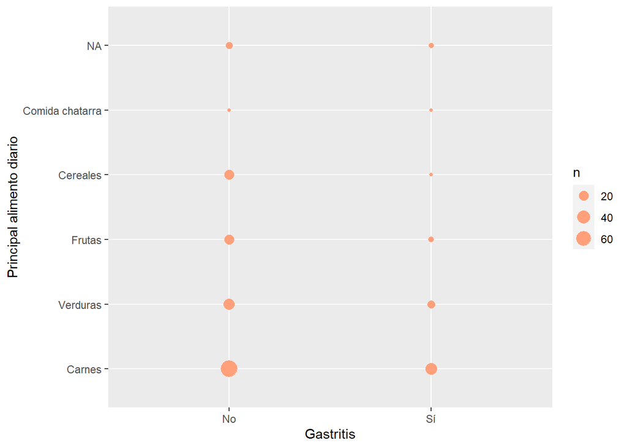

```r
ggplot(data=BDD2)+
  geom_count(aes(Gastritis,`Principal alimento diario`, main="Principal alimento / Gastritis" ),colour = "lightsalmon1", fill = "red")
```

# Teoría de conteo

## Análisis combinatorio

### *Ejercicio 1*

UTEC Ventures dentro de su equipo cuentan con 10 estudiantes que tienen un buen habito alimenticio, de ellos se va a seleccionar un comité de 3 estudiantes, el cual se llamara “Alimentación del futuro” todo esto para que brinden charlas a sus demás compañeros como también impulsar startups que tengan soluciones innovadoras ¿De cuántas formas diferentes se puede seleccionar el comité?

n=10(Cantidad de estudiantes que hay)

r=3(Cantidad de alumnos a escoger)

```r
combinar<- function(n,r){
  factorial(n)/(factorial(r)*factorial(n-r))
}
combinar(10,3)
```

```
## [1] 120
```

Respuesta: Se puede seleccionar el comite de 120 formas diferentes.

### *Fundamentación:*

Alicorp tiene una alianza con la aceleradora de la Universidad de Ingeniería y Tecnología (UTEC Ventures) para poder crear su programa de innovación abierta “Alimentación del futuro” que su propósito es impulsar a startups que tengan soluciones innovadoras en el sector alimentos y desarrollen el futuro del sector en Latinoamérica.

### *Fuente:*

[Alianza con UTEC Venture](https://enalimentos.lat/noticias/3404-alicorp-firma-alianza-con-utec-ventures-para-crear-programa-alimentacion-del-futuro.html)

# Variable aleatorias Discretas

## Modelo Binomial

### *Ejercicio 1*

Una investigación de estudiantes de Medicina del INTEC reveló que 65% de los jóvenes que realizan estudios universitarios consume comida chatarra de manera excesiva. Calcule la probabilidad de que en una muestra de 205 estudiantes haya menos de 133 estudiantes que consuman con mayor frecuencia comida chatarra.

*Éxito:* Estudiantes que consuman con mayor frecuencia comida chatarra.

*Fracaso:* Estudiantes que consuman con menor frecuencia comida chatarra.

*Fundamento:* Se aplicarán 133 estudiantes debido a que según la investigación del Intec nos revela que el 65% consume comida chatarra de manera excesiva y el 65% del total de nuestros encuestados es 133.

```r
pbinom(132,205,0.65)
```

```
## [1] 0.4534206
```

*Esperanza*E(X)= n.p

```r
E<-(205*0.65)
E
```

```
## [1] 133.25
```

*Varianza*V(X)= n.p.q

```r
V<-(205*0.65*0.35)
V
```

```
## [1] 46.6375
```

Respuesta -> La probabilidad de que en una muestra de 205 estudiantes haya menos de 133 estudiantes que consuman con mayor frecuencia comida chatarra es 45%.

### Fuente:

[Porcentaje de estudiantes que consumen comida rápida de manera excesiva](https://www.dicyt.com/noticias/el-horario-de-los-universitarios-eleva-su-consumo-de-comida-rapida)

### *Ejercicio 2*

La OMS (s.f.) recomienda ingerir entre 2 a 2.5 litros de agua vasos de agua. Según un estudio de la universidad Federico Villareal el 43% de universitarios consume 1l de agua. Calcule la probabilidad de que en una muestra de 205 estudiantes haya más de 88 estudiantes que consuma 1l de agua al día.

*Éxito:* Estudiantes que consuman 1l de agua al día.

*Fracaso:* Estudiantes que consuman más de 1l de agua al día.

*Fundamento:* Se aplicará la probabilidad con 88 estudiantes debido a que según el estudio de la universidad Federico Villareal el 43% de universitarios consumen 1l de agua al día y el 43% del total de nuestros encuestados es 88.

```r
Y<-(205*43)/100
round(Y,0)
```

```
## [1] 88
```

```r
round(pbinom(88,205,0.43,lower.tail = F),2)
```

```
## [1] 0.48
```

*Respuesta*-> La probabilidad de que en una muestra de 205 estudiantes haya más de 88 estudiantes que consuman 1l de agua al día es 0.48. Fuente

### Fuentes:

[Recomendaciones de la OMS](https://www.fundacionaquae.org/wiki/cuanta-agua-beber-dia/#:~:text=Seguro%20que%20has%20escuchado%20alguna,que%20hay%20tener%20en%20cuenta.) [Estudios de la universidad Villareal](https://repositorio.unfv.edu.pe/handle/UNFV/5083)

## Modelo Binomial Negativo

### *Ejercicio 1:*

¿Sabía usted que más del 80% de la población mundial sufre de gastritis? Datos frecuentes de la Organización Mundial de la Salud muestran que esta enfermedad es una de las consultas más frecuentes en el mundo. Entre las cusas más comunes están el desorden alimenticio y el consumo de comidas chatarra. En la UTEC se realizó una encuesta a una muestra de los estudiantes para averiguar si estos padecen de gastritis. En donde se obtuvo que el 25% la padece. En el salón 11.1 del curso de Estadística y probabilidades se revisó cada una de las respuestas de los estudiantes en la cual se evidencia que 10 alumnos padecen de gastritis. Entonces ¿Cuál es la probabilidad de que, al revisar las respuestas de los estudiantes, obtengamos que 2 de estos no padezcan de gastritis?

Tenemos que:

x= Número de respuestas Bernoulli hasta obtener el r éxito —-> 10

r= Es el éxito de no padecer gastritis ——->2

```r
round(dnbinom(10-2,2,0.25),2)
```

```
## [1] 0.06
```

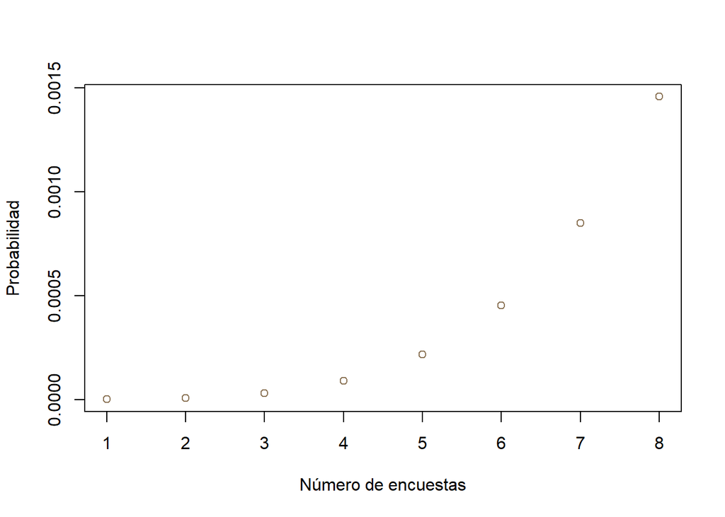

```r
plot(dnbinom(c(0:7),10,0.25),xlab="Número de encuestas",ylab="Probabilidad", col="burlywood4")
```

Varianza:

```r
(2*((1-0.25))/(0.25*0.25))
```

```
## [1] 24
```

Respuesta: La probabilidad de que obtengamos 2 estudiantes que no padezcan gastritis es del 6%

### Fundamentación:

Fundamento: En el dato que nos brinda la organización mundial de salud de las personas que padecen gastritis está en relación de que de cada 10 personas 8 padecen gastritis. En este problema se decidió utilizar el mismo planteamiento, pero en nuestro caso el porcentaje de que las personas encuestadas padezcan gastritis es del 25%.

## Modelo Geométrico

Nomenclatura: $X ~ g(x;1,p)$

Representa el número de repeticiones que se requieren en el experimento, para que el primer éxito ocurra.

### *Ejercicio 1*

Un entrevistador tiene una tasa de acierto en su encuesta de encontrar a una persona con una dieta vegana del 3% por día. ¿Qué probabilidad hay que este día encuentre por primera vez a una persona vegana en su encuesta numero 7?

X (7)= El número de personas encuestadas hasta encontrar un estudiante con dieta vegana

p=0.03

```r
table(BDD2$`Tipo de dieta` )
```

```
##
##    Omnívoro      Vegana Vegetariana
##         186           7          12
```

```r
dgeom(7 , 0.03)
```

```
## [1] 0.02423949
```

Esperanza:

```r
1/0.03
```

```
## [1] 33.33333
```

Empleamos el porcentaje de 3% debido a que en nuestra muestra de 205 estudiantes solo el 3% tiene una dieta vegana, siendo esta 7 estudiantes.

## Modelo Hipergeométrico:

N= Total de los datos

K= Cantidad de elementos de interés (es lo que luego se pregunta a x)

n= Tamaño total de la muestra a simular

x= Valor que toma la variable

### *Ejercicio 1:*

Se toma una encuesta a 205 estudiantes sobre si conocen cuantas calorías ingieren al día , de los cuales 80 si saben cuántas calorías ingieren, si se escogen 125 estudiantes encuestados

¿Calcule la probabilidad de encontrar a 45 estudiantes que sepan cuantas calorías ingieren?

P(X=45)

N=205

K=80

```r
table(BDD2$`Conocimiento de calorias diarias`)
```

```
##
##  No  Sí
## 125  80
```

```r
round(dhyper(45,80,205-80,125),2)
```

```
## [1] 0.06
```

Esperanza:

```r
(45*80)/205
```

```
## [1] 17.56098
```

Respuesta->La probabilidad de encontrar a 45 estudiantes que si sepan las calorías que consumen es de 6%.

### Fundamentación:

Se empleará el numero 80 ya que, en nuestra muestra de 205 personas, 80 son las que si conocen cuantas calorías consumen y 125 son las que no saben cuántas calorías consumen.